# Statistical tests

Leona Vracar

```r
# Function for EDA of single variables
EDA <- function(vect) {
  result <- list(
    mean = mean(vect),
    median = median(vect),
    variance = var(vect),
    sd = sd(vect),
    IQR = IQR(vect),
    min = min(vect),
    max = max(vect),
    range = max(vect) - min(vect)
  )
  return(result)
}
```

```r
plots_function <- function(input_vect, var_name = "default"){
  par(mfrow = c(2,2), mar = c(4.5, 4.5, 3, 1))

  boxplot(
    input_vect,
    main = paste("Boxplot of", var_name),
    col = "lightgreen",
    horizontal = TRUE
  )
  # Histogram
  hist(
    input_vect,
    main = paste("Histogram of", var_name),
    xlab = var_name,
    col = "lightblue",
    freq = FALSE
  )
  lines(density(input_vect), col = "red", lwd = 2)  #density curve

  # Q-Q
  qqnorm(
    input_vect,
    main = paste("Q-Q Plot of", var_name),
    col = "blue"
  )
  qqline(input_vect, col = "red", lwd = 2)

  # ECDF
  plot(
    ecdf(input_vect),
    main = paste("ECDF of", var_name),
    xlab = var_name,
    ylab = "ECDF"
  )

  # Reset layout back to normal 1x1
  par(mfrow = c(1, 1))
}
```

```r
# function for correlation matrix

cor_matrix <- function(data) {
  result <- cor(data, use = "pairwise.complete.obs")  #NA values will be excluded pairwise
  print(result)
  heatmap(result, main = "Correlation Matrix", col = colorRampPalette(c("blue", "white", "red"))(20))
}
```

```r
# function for scatterplot matrix
scatter_matrix <- function(data, main_title = "Scatterplot Matrix", point_color = "darkblue", point_size = 0.8) {
  pairs(
    data,
    main = main_title,
    col = point_color,
    cex = point_size
  )
}
```

# 1 Lab training for employees

A lab sent employees to a pipetting training and wishes to test if the training was worthwhile by measuring the average times needed to complete 25 pipetting tasks **before** and **after** the training for individual employees (total of 10 employees).

## 1.1 EDA

```r
before <- c(1.36, 1.37, 1.29, 1.22, 1.38, 1.31, 1.40, 1.39, 1.30, 1.37)
after <- c(1.29, 1.25, 1.20, 1.26, 1.25, 1.23, 1.26, 1.31, 1.24, 1.31)
#difference <- after - before
eda_before <- EDA(before)
eda_after <- EDA(after)
#eda_difference <- EDA(difference)

# Create a data frame and round the values
eda_results <- data.frame(
  Before = round(unlist(eda_before), 3),
  After = round(unlist(eda_after), 3)
  #Difference = round(unlist(eda_difference), 3)
)

# Display the table
knitr::kable(eda_results, caption = "Summary of EDA Results")
```

Summary of EDA Results

|  | Before | After |
| --- | --- | --- |
| mean | 1.339 | 1.260 |
| median | 1.365 | 1.255 |
| variance | 0.003 | 0.001 |
| sd | 0.057 | 0.035 |
| IQR | 0.075 | 0.040 |
| min | 1.220 | 1.200 |
| max | 1.400 | 1.310 |
| range | 0.180 | 0.110 |

The EDA statistics suggest a reduction in pipetting time as both the mean and median are lower in the after-training dataset.

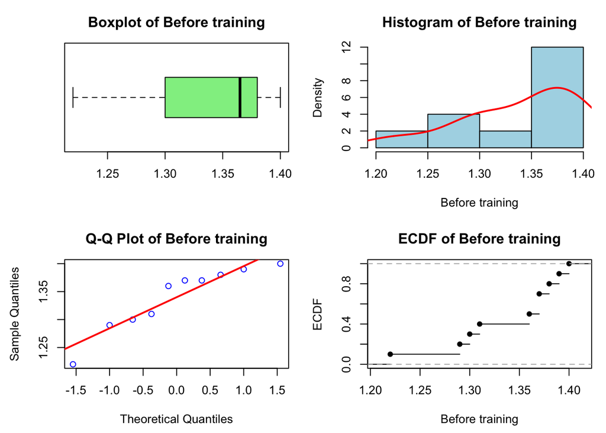

```r
plots_function(before, "Before training")
```

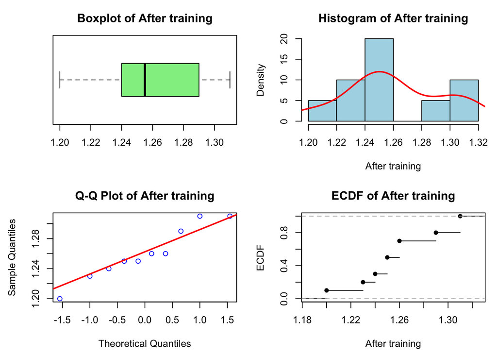

```r
plots_function(after, "After training")
```

**QQ-Plot**:

From the QQ-Plots both before and after training, it is difficult to make a definitive decision about the normality of the data. Since the dataset contains only 10 measurements, it is possible that the deviations from the red Q-Q line are due to natural variation that still falls within the range expected for a normal distribution.

## 1.2 Test approach

Because the two samples are paired, we have two main options for testing the statistical significance of the observed difference in means. First, the parametric Student’s t-test if data is normally distributed and second, the Wilcoxon-Rank Sum Test if the data deviates from normality. Therefore, before we make the choice, we have to check if the data is sampled from a normal distribution.

### 1.2.1 Shapiro-Wilks Test to check normality

For the Shapiro-Wilks Test, the null hypothesis is that the data forms a normal distribution. If the p-value is greater than 0.05, we will not reject the null hypothesis i.e. the data is normal.

```r
sw_before <- shapiro.test(before)
sw_after <- shapiro.test(after)
```

```r
sw_before
```

```
##
##  Shapiro-Wilk normality test
##
## data:  before
## W = 0.88588, p-value = 0.1523
```

The p-value of 0.152 > 0.05 hence we fail to reject the null hypothesis. The before data is normal.

```r
sw_after
```

```
##
##  Shapiro-Wilk normality test
##
## data:  after
## W = 0.9416, p-value = 0.571
```

The p-value of 0.571 is > 0.05 hence the after data is also normal.

Now that normality for both before- and after-training data has been confirmed, we proceed with the paired t-test.

### 1.2.2 Formulating hypotheses and performing the test

First, we’re going to look at the significance of the mean difference without assuming the direction of the mean difference.

**Null Hypothesis (**$H_0$): The pipetting training led to no change in mean pipetting time.

$$\mu_{\text{before}} = \mu_{\text{after}} \quad \text{or} \quad
\mu_{\text{difference}} = 0$$

**Alternative Hypothesis (**$H_A$): The pipetting training led to a statistically significant change in mean pipetting time.

$$\mu_{\text{before}} \neq \mu_{\text{after}} \quad \text{or} \quad
\mu_{\text{difference}} \neq 0$$

### 1.2.3 Paired t-test at the 5% confidence level

```r
t.test(before,after,paired = TRUE,conf.level = 0.95)
```

```
##
##  Paired t-test
##
## data:  before and after
## t = 4.9322, df = 9, p-value = 0.0008109
## alternative hypothesis: true mean difference is not equal to 0
## 95 percent confidence interval:
##  0.04276623 0.11523377
## sample estimates:
## mean difference
##           0.079
```

### 1.2.4 Paired t-test at the 1% confidence level

```r
t.test(before, after, paired = TRUE,conf.level = 0.99)
```

```
##
##  Paired t-test
##
## data:  before and after
## t = 4.9322, df = 9, p-value = 0.0008109
## alternative hypothesis: true mean difference is not equal to 0
## 99 percent confidence interval:
##  0.02694624 0.13105376
## sample estimates:
## mean difference
##           0.079
```

## 1.3 Interpretation

Since the p-value < 0.05 and < 0.01, we can reject the null hypothesis at both confidence levels. The mean difference in the after-training group compared to the before-training group is statistically significant.

The mean difference of 0.079 signifies a decrease from before-testing to after-testing (R calculates this value by subtracting the before and after values, hence if before > after we get a positive mean difference).

To specifically test if the training *reduced* pipetting times, we reformulate the hypotheses and perform a one-tailed paired t-test.

**Null Hypothesis (**$H_0$): The pipetting training led to no change or an increase in mean pipetting time.

$$\mu_{\text{before}} \leq \mu_{\text{after}} \quad \text{or} \quad
\mu_{\text{difference}} \leq 0$$

**Alternative Hypothesis (**$H_A$): The pipetting training led to a statistically significant decrease in mean pipetting time.

$$\mu_{\text{before}} > \mu_{\text{after}} \quad \text{or} \quad
\mu_{\text{difference}} > 0$$

### 1.3.1 One-tailed paired t-test at the 5% confidence level

```r
t.test(before, after, paired = TRUE, conf.level = 0.95, alternative = "greater")
```

```
##
##  Paired t-test
##
## data:  before and after
## t = 4.9322, df = 9, p-value = 0.0004055
## alternative hypothesis: true mean difference is greater than 0
## 95 percent confidence interval:
##  0.04963839        Inf
## sample estimates:
## mean difference
##           0.079
```

### 1.3.2 One-tailed paired t-test at the 1% confidence level.

```r
t.test(before, after, paired = TRUE, conf.level = 0.99, alternative = "greater")
```

```
##
##  Paired t-test
##
## data:  before and after
## t = 4.9322, df = 9, p-value = 0.0004055
## alternative hypothesis: true mean difference is greater than 0
## 99 percent confidence interval:
##  0.03380804        Inf
## sample estimates:
## mean difference
##           0.079
```

The **p-value** from the one-tailed t-test is **0.0004055**, which allows us to confidently **reject the null hypothesis** at both confidence levels. Additionally, the p-value from the one-tailed test (**0.0004055**) is approximately half the p-value from the two-tailed test (**0.0008109**).

The one-tailed test shows a lower p-value because the change in mean pipetting times is a statistically significant **decrease** more than just a significant change in either direction.

#### 1.3.2.1 Should the lab send employees to do this training in order to reduce their mean pipetting time?

We established that the positive mean difference is statistically significant i.e. that the training lead to a statistically significant decrease in pipetting times. However, it is unlikely that a 0.079 mean decrease in pipetting time for 25x pipette actions is economically viable to justify training for the employees. We cannot make any recommendation for the training based on pipetting time alone as there are many other reasons to train employees such as improving accuracy.

# 2 Survival Rate on the Titanic

## 2.1 Test approach

In this task, the survival rate of women and children is compared to the rate of men within significance level of 1%.

### 2.1.1 Formulating hypotheses and performing the test

H0: The mean survival rate of women and children is equal or less than the mean survival rate of men. HA: The mean survival rate of women and children is higher than the mean survival rate of men.

After loading the data, 3 subgroups are extracted for performing the statistical test.

```r
data("Titanic")
titanic_data <- as.data.frame(Titanic)
# extract 3 subgroups for further analysis
# count the survival and total rate
#women
survival_women <- sum((titanic_data$Survived == "Yes" & titanic_data$Sex == "Female") * titanic_data$Freq)
total_women <- sum((titanic_data$Sex == "Female") * titanic_data$Freq)
#men
survival_men <- sum((titanic_data$Survived == "Yes" & titanic_data$Sex == "Male") * titanic_data$Freq)
total_men <- sum((titanic_data$Sex == "Male") * titanic_data$Freq)
#children
survival_children <- sum((titanic_data$Survived == "Yes" & titanic_data$Age == "Child") * titanic_data$Freq)
total_children <- sum((titanic_data$Age == "Child") * titanic_data$Freq)
```

It is important to multiply the sum of the survival rate with the frequency, because it is the total number of appearances. The Proper Test is used, to check the survival probability between different groups. This test is based on the binomial distribution: there are two options, the person survived on titanic or died. The parameter p shows the portion of the success of n attempts.

```r
# Proportional Test
#prop.test(x,y, alternative = "greater")

#women vs. men
prop_women_men <- prop.test(c(survival_women, survival_men), c(total_women, total_men),
                                 alternative = "greater", conf.level = 0.99, correct = TRUE)
prop_women_men
```

```
##
##  2-sample test for equality of proportions with continuity correction
##
## data:  c(survival_women, survival_men) out of c(total_women, total_men)
## X-squared = 454.5, df = 1, p-value < 2.2e-16
## alternative hypothesis: greater
## 99 percent confidence interval:
##  0.4658044 1.0000000
## sample estimates:
##    prop 1    prop 2
## 0.7319149 0.2120162
```

```r
#children vs. men
prop_children_men <- prop.test(c(survival_children, survival_men), c(total_children, total_men),
                                    alternative = "greater", conf.level = 0.99, correct = TRUE)
prop_children_men
```

```
##
##  2-sample test for equality of proportions with continuity correction
##
## data:  c(survival_children, survival_men) out of c(total_children, total_men)
## X-squared = 54.16, df = 1, p-value = 9.24e-14
## alternative hypothesis: greater
## 99 percent confidence interval:
##  0.1924267 1.0000000
## sample estimates:
##    prop 1    prop 2
## 0.5229358 0.2120162
```

## 2.2 Interpretation

The x-squared test statistic of **women vs. men** is **454.5**. The p-value of **2.2e-16** shows, that with the significance level of **0.99** the null hypothesis (H0) has to be rejected. Meaning, that women on the Titanic had a higher survival rate than men.

# 3 Bacterial growth

A biologist is comparing the mean growth rate of a culture in a petri dish every minute over a timespan of 20 minutes.

The expected growth rate is 1% and the biologist wants to check if the used growth medium increases the growth rate.

```r
growth_rate <- c(0.146842, 0.156757, 0.091255, 0.063720, 0.148471, -0.045436, 0.150407, 0.077905, 0.077267, 0.026454, 0.090700, 0.245384, 0.129650, 0.141617, 0.039957, 0.165351, 0.029091, 0.073473, 0.189657, 0.123897)
```

## 3.1 EDA

```r
EDA(growth_rate)
```

```
## $mean
## [1] 0.106121
##
## $median
## [1] 0.107576
##
## $variance
## [1] 0.004450846
##
## $sd
## [1] 0.06671466
##
## $IQR
## [1] 0.07792025
##
## $min
## [1] -0.045436
##
## $max
## [1] 0.245384
##
## $range
## [1] 0.29082
```

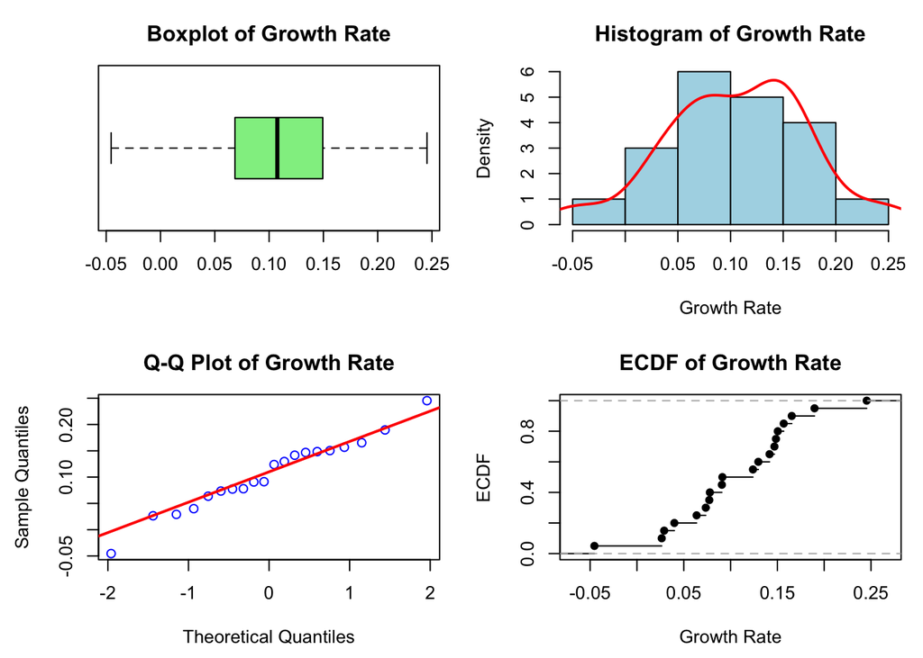

```r
plots_function(growth_rate, "Growth Rate")
```

The **mean** and **median** are close together, suggesting symmetry and no outliers. The Q-Q plot shows that the data is approximatelly normally distributed.

## 3.2 Test approach

Since the biologist is interested in finding out if the growth rate is higher compared to the expected 1% and the data is normally distributed, a one-sample, one-tailed t-test is the correct choice.

### 3.2.1 Formulating hypotheses and performing the test

**Null Hypothesis (**$H_0$): The mean growth rate is 1% or less.
$$\mu_{\text{0}} \leq 0.01$$

**Alternative Hypothesis (**$H_A$): The mean growth rate is greater than 1%.

$$\mu_{\text{A}} > 0.01$$

### 3.2.2 One-sample, one-tailed t-test at 95% confidence level

```r
t.test(growth_rate, alternative = c("greater"), mu = 0.01)
```

```
##
##  One Sample t-test
##
## data:  growth_rate
## t = 6.4434, df = 19, p-value = 1.774e-06
## alternative hypothesis: true mean is greater than 0.01
## 95 percent confidence interval:
##  0.080326      Inf
## sample estimates:
## mean of x
##  0.106121
```

### 3.2.3 Interpretation

The p-value is extremely small so we reject the null hypothesis. We would even reject the null hypothesis at a lower confidence level of 0.01. The increase in mean growth rate is statistically significant.

The observed mean growth rate is 0.1061209 or approximately 10.61%.

From the 95% confidence interval [0.080326, Inf], we can say that the true mean growth rate is at least 0.080326 or approximately 8.03% with a 95% confidence.

# 4 Gene ontology

## 4.1 EDA

There are 720 possible genes, of which only 696 are considered credible. 413 genes are associated with cancer development, which is approximately 59.3% of the credible genes. In a previous study, 55% of the genes were found to be involved.

The **estimator** is the relative frequency of successes $\hat{p} = \frac{m}{n}$, which in this case is $\hat{p} = \frac{413}{696} = 0,593$.

The **reference value** p0 is 0,55.

## 4.2 Selection of an appropriate test

As parametric test we choose the proportion test with one sample, because we have only two possible results (is associated with cancer development or not) and assume that the data has a binomial distribution.

## 4.3 Formulating hypotheses

The question is if the proportion of involved genes has significantly changed compared to a previous study, which found 55% of the genes to be involved.

So the hypotheses are stated as followed (two-sided):

H0: The proportion of involved genes is not significantly different from the 55% found in the previous study. ($H0:\hat{p} = 0,55$)

HA: The proportion of involved genes is significantly different from the 55% found in the previous study. ($HA:\hat{p} \neq 0,55$)

## 4.4 95% confidence intervals

```r
proportion <- 413/696
stichprobengroesse <- 696
quantilunten_95 <- qnorm(0.025,mean = 0,sd=1)
quantiloben_95 <- qnorm(0.975,mean = 0,sd=1)
KI95_unten <-proportion+quantilunten_95*sqrt((proportion*(1-proportion))/stichprobengroesse)
KI95_oben <- proportion+quantiloben_95*sqrt((proportion*(1-proportion))/stichprobengroesse)

quantilunten_99 <- qnorm(0.005, mean = 0, sd = 1)
quantiloben_99 <- qnorm(0.995, mean = 0, sd = 1)
KI99_unten <-proportion+quantilunten_99*sqrt((proportion*(1-proportion))/stichprobengroesse)
KI99_oben <- proportion+quantiloben_99*sqrt((proportion*(1-proportion))/stichprobengroesse)

prop.test(413,696, p=0.55)
```

```
##
##  1-sample proportions test with continuity correction
##
## data:  413 out of 696, null probability 0.55
## X-squared = 5.1207, df = 1, p-value = 0.02364
## alternative hypothesis: true p is not equal to 0.55
## 95 percent confidence interval:
##  0.5557580 0.6299782
## sample estimates:
##         p
## 0.5933908
```

## 4.5 99% confidence intervals

Per default settings the prop.test in R is set to a 95% confidence level, so to also get the 99% CI, the parameter conf.level is set to 0.99

```r
prop.test(413,696, p=0.55, conf.level=0.99)
```

```
##
##  1-sample proportions test with continuity correction
##
## data:  413 out of 696, null probability 0.55
## X-squared = 5.1207, df = 1, p-value = 0.02364
## alternative hypothesis: true p is not equal to 0.55
## 99 percent confidence interval:
##  0.5440439 0.6409477
## sample estimates:
##         p
## 0.5933908
```

### 4.5.1 Interpretation

The 95% confidence interval ranges from 55.6% to 63.0%. The 99% confidence interval ranges from 54.4% to 64.1%. The 95% CI does not include 55%, but the 99% CI does. This means that if a significance level of alpha = 0.05 is chosen, the difference is significant and the null hypothesis (H0) can be rejected. However, if alpha = 0.01 is chosen, the difference is not significant, and the null hypothesis cannot be rejected.

# 5 Salary comparisons

The data below shows the monthly salary of two different companies. In this analysis we want to find out, which company has the better salary. Therefore, we use data exploration and different test to find out.

```r
# save the data as a vector
Company_1 <- c(4218.874, 2323.970,
4104.761, 3172.519, 3058.287, 2386.729, 4405.709, 2665.709, 5326.124, 2993.015,
5152.121, 3164.876, 2703.269, 3837.005, 2927.137, 2847.995, 3087.938, 3063.339,
4697.341, 5602.379, 2992.996, 5052.060, 4095.423, 1668.059, 6268.097)

Company_2 <- c(1888.252, 2429.395, 2062.037, 1932.138, 1788.335, 2119.263,
2185.819, 2173.098, 2391.626, 1576.546, 1871.540, 2405.640, 2470.771, 1879.237,
2181.048, 2272.962, 2174.767, 1729.053, 1119.993, 2325.788, 2112.610, 2847.006,
1124.272, 5320.000, 4785.000)
```

## 5.1 EDA

```r
# Function for analysis of variables

EDA_company1 <- EDA(Company_1)
EDA_company2 <- EDA(Company_2)
```

**Location**: The Company 1 has a mean of **3672.63** and a median of **3164.88**. Company 2 has a mean of **2286.65** and a median of **2173.1**

**Spread/variation**: The data of the Company 1 has a standard deviation of **1168.45** which is smaller relative to the mean of **3672.63** . The IQR has a result of **1478.57**.

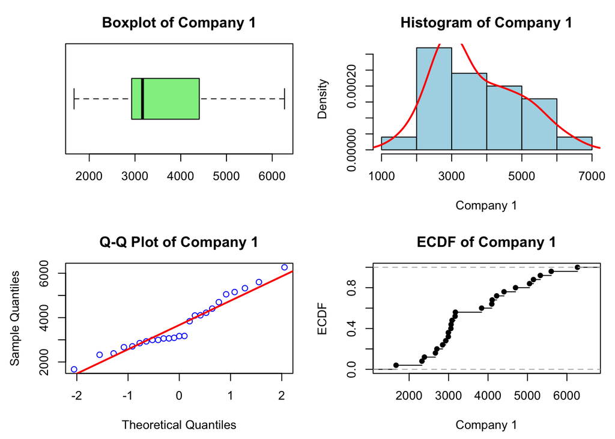

```r
plots_function(Company_1, var_name = "Company 1")
```

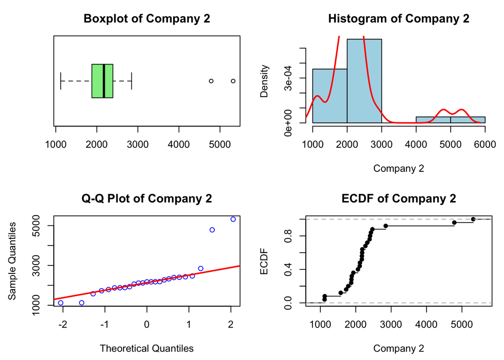

```r
plots_function(Company_2, var_name = "Company 2")
```

**Company 1**: In the boxplot there is a wide diversity of data in the Q3. The whiskers are long, because a lot of data is outside of the quantiles. The median is right next to the Q1. In the QQ-Plot of Company 1 a shift in the middle of the data is noticeable. The Shapiro-Wilk-Test recognize heavy tails and outliers and is based on unimodality Due to the shift in the middle, the the values is categorized into 2 salary classes and the Shapiro-Wilk-Test is not allowed here. This shift is also recognizable in the ECDF. This example shows the importance of data exploration.

**Company 2**: The two values outside of the boxplot whiskers can be detected in all plots. Especially, in the ECDF Plot the values are noticeable. Overall, the data is not normally distributed, due to the two heavy tails.

## 5.2 Test approach

Due to the data not being normally distributed, we cannot use the t-Test. The Mann-Whitney-U-Test is necessary for this analysis.Especially because the samples of both companies are independent of one another.

### 5.2.1 Formulating hypotheses and performing the test

**H0**: The salary median of company 1 is equal to the salary median of company 2.

**HA**: The salary median of company 1 is not equal to the salary median of company 2.

```r
# Mann-Whitney-U-Test
result_wilcox <- wilcox.test(Company_1, Company_2, exact = FALSE, correct = FALSE, conf.int = FALSE)
result_wilcox
```

```
##
##  Wilcoxon rank sum test
##
## data:  Company_1 and Company_2
## W = 550, p-value = 4.062e-06
## alternative hypothesis: true location shift is not equal to 0
```

### 5.2.2 Interpretation

To interpret the results, we look at the median salaries of the two companies. The median of Company 1 is **3164.88** and of Company 2 **2173.1**.

Company 1 has a higher median than company 2. Since the median is the reliable measure for locus in this example (it is robust and not sensitive to outliers), we can conclude that company 1 offers a better median salary than company 2.